# re_airquality

David Fäh 23-106-396

2025-03-05

## Introduction

```r
# load libraries
library(tidyverse)
```

**The airquality data set:** Airquality is a data set built into R. It contains daily measurements of the atmosphere taken in New York City in 1973 from May 1st to September 30th.

The measured variables are:

- Ozone [ppb]
- Solar.R [Ly]
- Wind [mph]
- Temp [°F]
- Month [numeric]
- Day [numeric]

```r
# load data set airquality
airquality <- datasets::airquality
```

**An overview of the data set:**

```r
# present the first few rows
knitr::kable(head(airquality))
```

| Ozone | Solar.R | Wind | Temp | Month | Day |
| --- | --- | --- | --- | --- | --- |
| 41 | 190 | 7.4 | 67 | 5 | 1 |
| 36 | 118 | 8.0 | 72 | 5 | 2 |
| 12 | 149 | 12.6 | 74 | 5 | 3 |
| 18 | 313 | 11.5 | 62 | 5 | 4 |
| NA | NA | 14.3 | 56 | 5 | 5 |
| 28 | NA | 14.9 | 66 | 5 | 6 |

The data set includes 153 observations within 6 variables in total. But there are missing values in the Ozone and Solar.R variables. Given the relatively small number of observations, I do not interpolate values but drop rows containing NA.

**My cleaned data contains:**

- 6 Variables
- 111 Observations

```r
# clean data
airquality_clean <- airquality |> drop_na()
```

### My hypotheses:

- Higher solar radiation increases ozone concentration as it catalyzes ozone formation.
- Higher temperatures accelerate ozone formation, creating a seasonal trend with higher values in summer.
- Higher wind speeds reduce ozone concentration by dispersing the molecules.

## Analysis

To gain an overview over the cleaned data set and over the remaining values, I plot the distribution of observations by month.

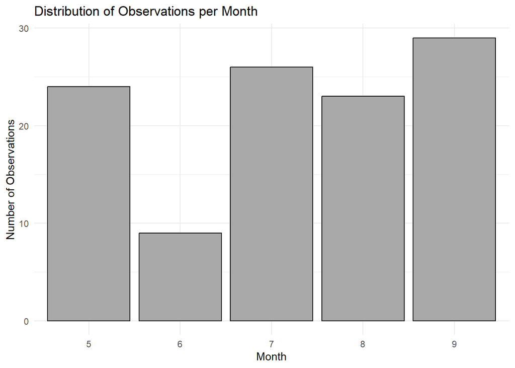

```r
ggplot(
  data = airquality_clean,
  aes(x = factor(Month))) +
  geom_bar(fill = "darkgrey", color = "black") +
  labs(
    x = "Month",
    y = "Number of Observations",
    title = "Distribution of Observations per Month") +
  theme_minimal()
```

June has very few observations, which makes it harder to compare months and could influence with the overall trend.

Next, I will analyze the variation in ozone concentration by calculating the standard deviation.

```r
# calculate standard deviation
ozone_sd <- sd(airquality_clean$Ozone)

# present result
cat("The ozone standard deviation is:", round(ozone_sd, digits = 2))
```

```
## The ozone standard deviation is: 33.28
```

The high variability suggests that weather conditions may affect ozone concentration. To identify seasonal trends, I plot the ozone distribution for each month.

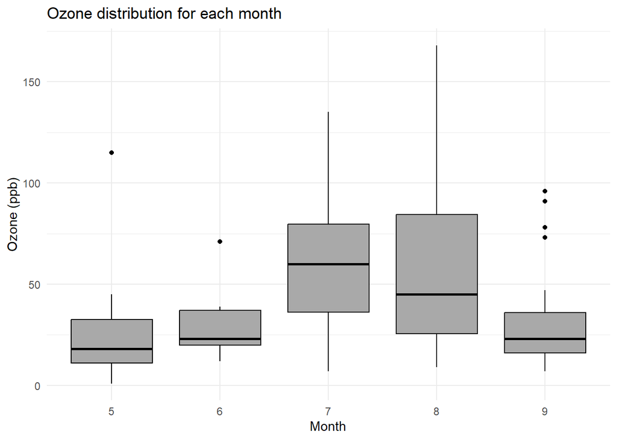

```r
# plot distribution for each month
ggplot(
  data = airquality_clean,
  aes(x = factor(Month), y = Ozone)) +
  geom_boxplot(fill = "darkgrey", color = "black") +
  labs(
    x = "Month",
    y = "Ozone (ppb)",
    title = "Ozone distribution for each month") +
  theme_minimal()
```

The boxplots support the hypothesis of rising ozone concentrations during the summer months. The large difference in means between June and July might be due to little observations in June. The increase could be due to both higher solar radiation and temperatures.

To explore this, I analyze the correlation between ozone, solar radiation, and temperature using scatter plots.

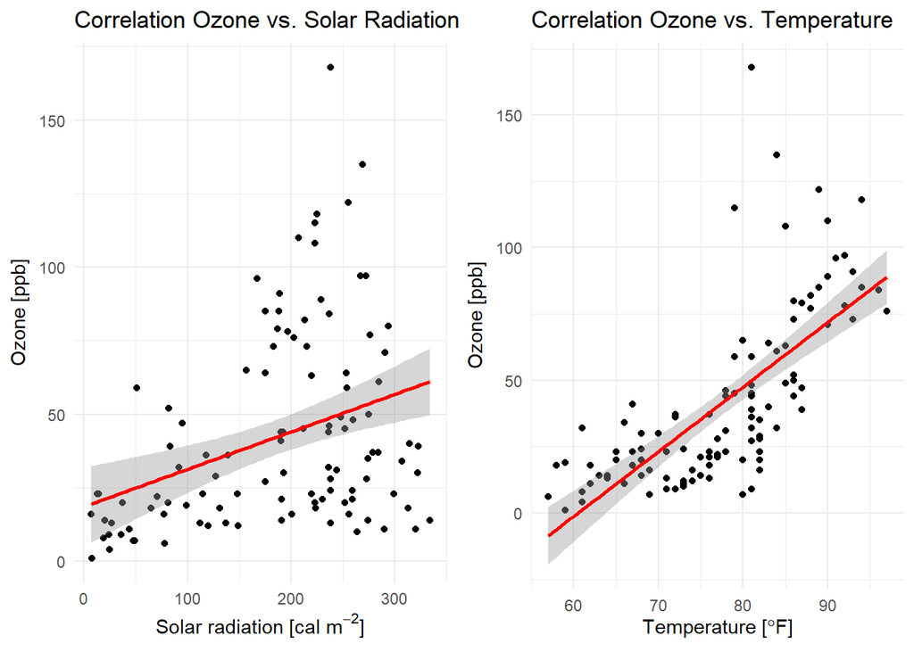

```r
# plot correlation between ozone and solar radiation
plot_solar_radiation <- ggplot(
  data = airquality_clean,
  aes(x = Solar.R, y = Ozone)) +
  geom_point() +
  geom_smooth(method = "lm", color = "red") +
  labs(
    title = "Correlation Ozone vs. Solar Radiation",
    x = expression(paste("Solar radiation [cal m"^-2, "]")),
    y = expression(paste("Ozone [ppb]"))) +
  theme_minimal()


# plot correlation between ozone and temperature
plot_temp <- ggplot(
  data = airquality_clean,
  aes(x = Temp, y = Ozone)) +
  geom_point() +
  geom_smooth(method = "lm", color = "red") +
  labs(
    title = "Correlation Ozone vs. Temperature",
    x = expression(paste("Temperature [", degree, "F]")),  # Using 'degree' for the degree symbol
    y = expression(paste("Ozone [ppb]"))) +
  theme_minimal()


# Combine plots side by side
cowplot::plot_grid(plot_solar_radiation, plot_temp, ncol = 2)
```

The regression line (red) suggests a stronger correlation between ozone concentration and temperature compared to the correlation between ozone concentration and solar radiation.

To quantify this, I calculate the Pearson correlation coefficient for both variables.

```r
# calculate pearson correlation coefficients
cor_solar <- cor(x = airquality_clean$Ozone, y = airquality_clean$Solar.R, method = "pearson")
cor_temp <- cor(x = airquality_clean$Ozone, y = airquality_clean$Temp, method = "pearson")

# store results in a data frame
pearson_cor <- data.frame(
  Correlated_Variables = c("Ozone vs Solar Radiation", "Ozone vs Temperature"),
  Pearson_Correlation = c(cor_solar, cor_temp))

# present pearson correlation coefficients
knitr::kable(pearson_cor)
```

| Correlated_Variables | Pearson_Correlation |
| --- | --- |
| Ozone vs Solar Radiation | 0.3483417 |
| Ozone vs Temperature | 0.6985414 |

Since temperature shows a stronger correlation with ozone concentration, I will focus on this relationship for further analysis.

Next, I will consider the effect of wind by incorporating it into the correlation plot using the color aesthetic.

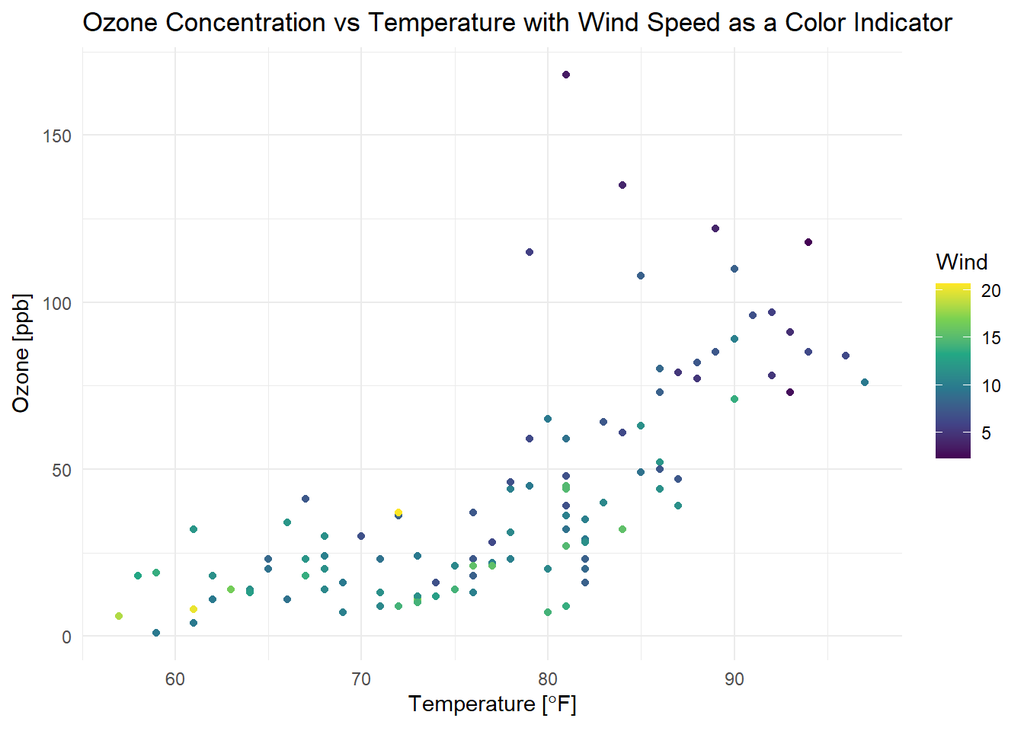

```r
# plot ozone concentration vs temperature, incorporating wind speed through color
ggplot(
  data = airquality_clean,
  aes(x = Temp, y = Ozone, colour = Wind)) +
  geom_point() +
  scale_color_viridis_c() +
  labs(
    title = "Ozone Concentration vs Temperature with Wind Speed as a Color Indicator",
    x = expression(paste("Temperature [", degree, "F]")),  # Using 'degree' for the degree symbol
    y = expression(paste("Ozone [ppb]"))) +
  theme_minimal()
```

This negative correlation between ozone levels and wind speeds supports my hypothesis.

## Conclusion

Missing values complicated month-to-moth comparison. However, a seasonal trend in local ozone concentration, peaking in the months July and August could be observed. These high values show a positive relation to both temperature and solar radiation. Temperature correlates stronger than solar radiation. I could not answer why that is the case. Further, ozone concentration correlates negative to the wind speed.